# Cross_validation_and_Bayes_Homework

Wendi White

10/25/2020

github– https://github.com/wendi-white/biol607_homework

```r
#libraries
library(ggpmisc)
```

```r
library(ggplot2)
library(tidyr)
library(rsample)
library(dplyr)
library(purrr)
library(modelr)
library(boot)
library(AICcmodavg)
```

For today, we’ll consider data from Brutsaert et al. 2002 looking at how progestrone levels influence respiration at altitude. The data can be downloaded here with progestrone levels and ventilation as a metric of breathing.

```r
setwd("/Users/wendiwhite/Desktop/Ecology/UMass Boston Masters/UMass Masters classes/bio stats 607/data")

breathing <- read.csv("chap17q07ProgesteroneExercise.csv") #read in CSV
breathing
```

```
##    progesterone ventilation
## 1           9.8        62.1
## 2          13.8        55.8
## 3          17.3        57.7
## 4          22.5        58.1
## 5          12.7        65.3
## 6          20.2        66.4
## 7          20.4        68.6
## 8          23.3        69.3
## 9          32.9        58.8
## 10         37.5        65.6
## 11         35.2        72.3
## 12         54.2        64.1
## 13         59.4        59.3
## 14         78.3        53.4
```

[output cut: 16 more lines]

1. Create models with different polys Let’s first look at the data. Plot it, along with a polynomial fit (remember, formula = y ~ poly(x,2) for a quadratic). Then, compare the r2 value of a linear versus fifth order fit. What do you see?

linear R2= 0.24 5th order poly R2= 0.27

We see that the 5th order poly is a slightly better fit.

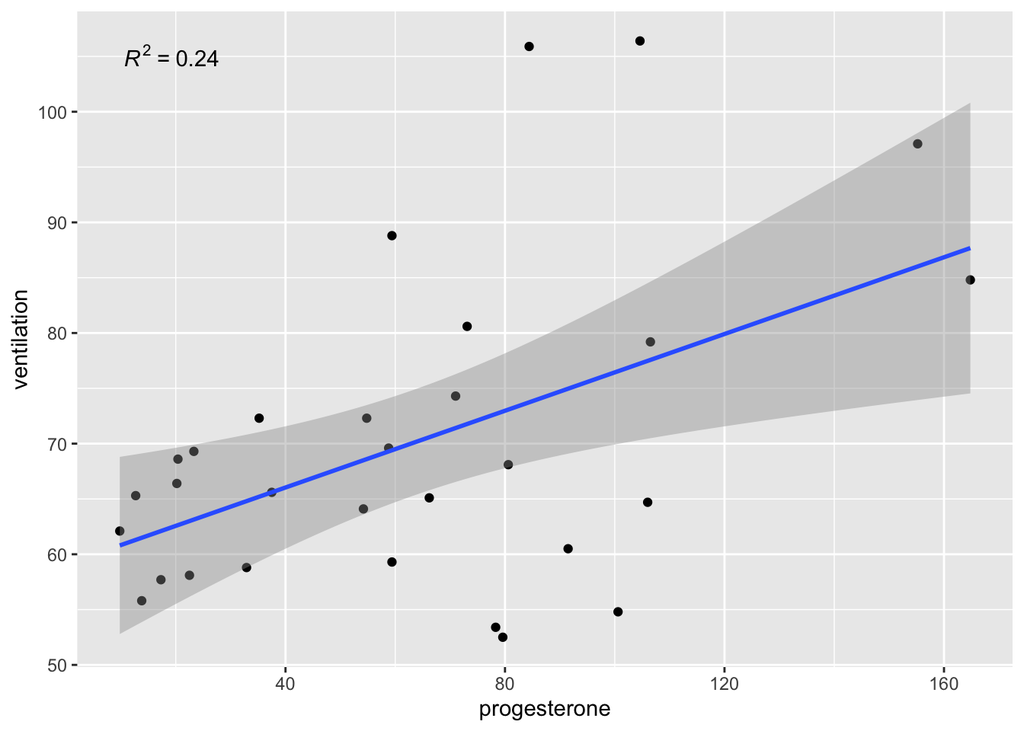

```r
breathing_plotted <- ggplot(data=breathing, #plot
                            mapping = aes(x=progesterone,
                                          y=ventilation)) +
    geom_point() +
    stat_smooth(method = "lm", formula = y ~ x)+ #linear formula
    stat_poly_eq(formula = y ~ x, parse = TRUE) #get r2 value on graph with linear eq
breathing_plotted
```

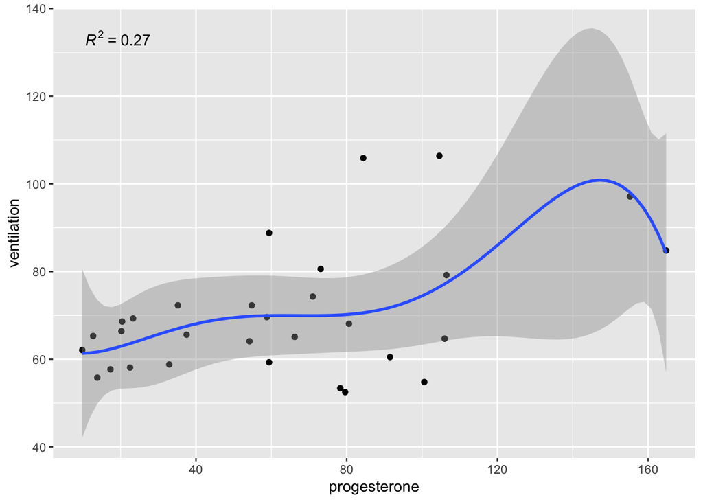

```r
breathing_plotted_2 <- ggplot(data=breathing, #plot
                            mapping = aes(x=progesterone,
                                          y=ventilation)) +
    geom_point()+
    stat_smooth(method= "lm", formula = y ~ poly(x, 5))+ #same as above but                                                          eq now for                                                                    5th order fit
    stat_poly_eq(formula = y ~ poly(x, 5), parse = TRUE)
breathing_plotted_2
```

2. Fit each model with 5-fold CV Does that result hold up, or is it due to overfitting? Let’s evaluate by comparing 5-fold CV scores using RMSE. Let’s do this efficiently, though!

A. Get things ready! Make a 5-fold cross validation tibble using rsample::vfold_cv() and then combine each possible fold with the polynomials 1:5 using tidyr::crossing()

```r
five_fold_tibb_breath <- vfold_cv(data =breathing, v=5)%>% #create five folds
  crossing(p=1:5) #do a cross of the folds with polynomials
five_fold_tibb_breath
```

```
## # A tibble: 25 x 3
##    splits         id        p
##    <list>         <chr> <int>
##  1 <split [24/6]> Fold1     1
##  2 <split [24/6]> Fold1     2
##  3 <split [24/6]> Fold1     3
##  4 <split [24/6]> Fold1     4
##  5 <split [24/6]> Fold1     5
##  6 <split [24/6]> Fold2     1
##  7 <split [24/6]> Fold2     2
##  8 <split [24/6]> Fold2     3
##  9 <split [24/6]> Fold2     4
## 10 <split [24/6]> Fold2     5
## # … with 15 more rows
```

B. Now you have splits and a column of coefficients. Use purr::map2() to make a list column of fit models, where you use the splits and data and the polynomials for you poly() call in the model.

```r
five_fold_tibb_breath <- five_fold_tibb_breath %>% #take table
  mutate(fit_models= map2(.x=splits, #create a new model that creates a lm of the folds and polynomials
                          p,
                          ~lm(ventilation~poly(progesterone,.y),
                          data= analysis(.x))))
five_fold_tibb_breath
```

```
## # A tibble: 25 x 4
##    splits         id        p fit_models
##    <list>         <chr> <int> <list>
##  1 <split [24/6]> Fold1     1 <lm>
##  2 <split [24/6]> Fold1     2 <lm>
##  3 <split [24/6]> Fold1     3 <lm>
##  4 <split [24/6]> Fold1     4 <lm>
##  5 <split [24/6]> Fold1     5 <lm>
##  6 <split [24/6]> Fold2     1 <lm>
##  7 <split [24/6]> Fold2     2 <lm>
##  8 <split [24/6]> Fold2     3 <lm>
##  9 <split [24/6]> Fold2     4 <lm>
## 10 <split [24/6]> Fold2     5 <lm>
## # … with 15 more rows
```

C. Great! Now, calculate the rmse for each fold/polynomial combination as we did in lab.

```r
five_fold_tibb_breath_rmse <- five_fold_tibb_breath %>%
  #create new col rmse with map2 iterating over all splits
    #and fit models
  mutate(rmse = map2_dbl(.x= splits, .y= fit_models, #split x , mod y
                          #model is .y b/c mod is our second arg
                        ~rmse(model = .y, data = assessment(.x))))
five_fold_tibb_breath_rmse
```

```
## # A tibble: 25 x 5
##    splits         id        p fit_models  rmse
##    <list>         <chr> <int> <list>     <dbl>
##  1 <split [24/6]> Fold1     1 <lm>        5.82
##  2 <split [24/6]> Fold1     2 <lm>        6.58
##  3 <split [24/6]> Fold1     3 <lm>        6.62
##  4 <split [24/6]> Fold1     4 <lm>        9.87
##  5 <split [24/6]> Fold1     5 <lm>        9.03
##  6 <split [24/6]> Fold2     1 <lm>        8.44
##  7 <split [24/6]> Fold2     2 <lm>        8.42
##  8 <split [24/6]> Fold2     3 <lm>        8.47
##  9 <split [24/6]> Fold2     4 <lm>        8.59
## 10 <split [24/6]> Fold2     5 <lm>        7.96
## # … with 15 more rows
```

D. Implications - ok, given that the 5-fold score is the average RMSE across all folds for a given polynomial, show in both a table and figure the relationship between polynomial and out-of-sample RMSE. What does this tell you?

```r
rmse_table <- five_fold_tibb_breath_rmse %>% #take dataset with rmse col
  group_by(p) %>% #group by poly
  summarize(per_fold_mean= unique(mean(rmse))) #get mean for each poly
rmse_table
```

```
## # A tibble: 5 x 2
##       p per_fold_mean
##   <int>         <dbl>
## 1     1          12.1
## 2     2          12.5
## 3     3          12.7
## 4     4          13.6
## 5     5          13.0
```

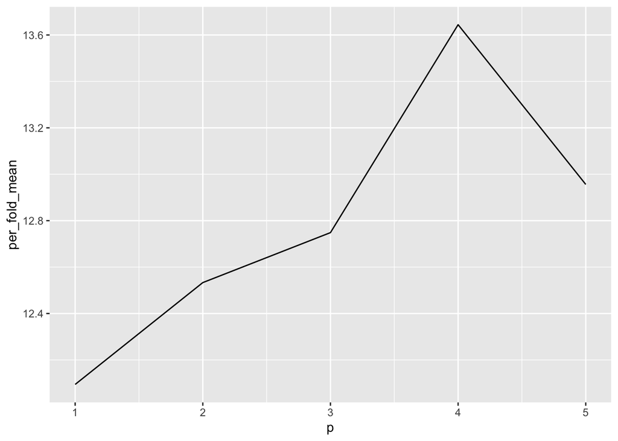

```r
plot_rmse <- ggplot(data = rmse_table, #plot how the mean RMSE changes across our diff folds
                    mapping = aes(x=p,
                                  y=per_fold_mean)) +
    geom_line()
plot_rmse
```

3. Compare models and see how they differ from AIC That was all well and good, but, how to these results compare to doing this analysis with AIC using the {AICcmodavg} package? Note, you can use dplyr and purrr to not have to fit each model manually.

```r
breath_lm <- lm(ventilation~progesterone, data=breathing) #lm for each poly
breath_int <-  lm(ventilation~1, data=breathing)
breath_sq <- lm(ventilation~poly(progesterone, 2), data=breathing)
breath_cub <- lm(ventilation~poly(progesterone, 3), data=breathing)
breath_four <- lm(ventilation~poly(progesterone, 4), data=breathing)
breath_five <- lm(ventilation~poly(progesterone, 5), data=breathing)

mod_list <- list(breath_int, breath_lm, breath_sq, breath_cub, breath_four, breath_five) #make a list of our lm and then make into a vector
name_vec <- c("int", "linear", "quad", "cube", "quad", "quin")

aictab(cand.set = mod_list, modnames=name_vec) #get AIC values for poly 1-5
```

```
##
## Model selection based on AICc:
##
##        K   AICc Delta_AICc AICcWt Cum.Wt      LL
## linear 3 242.86       0.00   0.69   0.69 -117.97
## quad   4 245.29       2.43   0.20   0.89 -117.85
## cube   5 248.16       5.31   0.05   0.94 -117.83
## int    2 248.50       5.64   0.04   0.98 -122.03
## quad   6 250.72       7.87   0.01   1.00 -117.54
## quin   7 253.52      10.66   0.00   1.00 -117.21
```

5. Grid sample with Bayes Last week, we did grid sampling with Likelihood. This week, let’s do it with Bayes!

A. Let’s start with the Palmer Penguins data. Let’s look at just the Gentoo. Why don’t you plot the distribution of the average flipper length of females. We’ll use this data for the exercise. Remember to remove NAs - it will make the rest of the exercise easier. 1 EC for each thing you do to snaz the plot up.

```r
penguins <- palmerpenguins::penguins
penguins <- penguins %>%
  filter(species == "Gentoo", na.rm=TRUE) #filter for Gentoo
summary(penguins)
```

```
##       species          island    bill_length_mm  bill_depth_mm
##  Adelie   :  0   Biscoe   :124   Min.   :40.90   Min.   :13.10
##  Chinstrap:  0   Dream    :  0   1st Qu.:45.30   1st Qu.:14.20
##  Gentoo   :124   Torgersen:  0   Median :47.30   Median :15.00
##                                  Mean   :47.50   Mean   :14.98
##                                  3rd Qu.:49.55   3rd Qu.:15.70
##                                  Max.   :59.60   Max.   :17.30
##                                  NA's   :1       NA's   :1
##  flipper_length_mm  body_mass_g       sex          year
##  Min.   :203.0     Min.   :3950   female:58   Min.   :2007
##  1st Qu.:212.0     1st Qu.:4700   male  :61   1st Qu.:2007
##  Median :216.0     Median :5000   NA's  : 5   Median :2008
##  Mean   :217.2     Mean   :5076               Mean   :2008
##  3rd Qu.:221.0     3rd Qu.:5500               3rd Qu.:2009
##  Max.   :231.0     Max.   :6300               Max.   :2009
##  NA's   :1         NA's   :1
```

```r
penguins_fem <- penguins %>%
  filter(sex == "female", na.rm=TRUE) #filter for females
summary(penguins_fem)
```

```
##       species         island   bill_length_mm  bill_depth_mm
##  Adelie   : 0   Biscoe   :58   Min.   :40.90   Min.   :13.10
##  Chinstrap: 0   Dream    : 0   1st Qu.:43.85   1st Qu.:13.80
##  Gentoo   :58   Torgersen: 0   Median :45.50   Median :14.25
##                                Mean   :45.56   Mean   :14.24
##                                3rd Qu.:46.88   3rd Qu.:14.60
##                                Max.   :50.50   Max.   :15.50
##  flipper_length_mm  body_mass_g       sex          year
##  Min.   :203.0     Min.   :3950   female:58   Min.   :2007
##  1st Qu.:210.0     1st Qu.:4462   male  : 0   1st Qu.:2007
##  Median :212.0     Median :4700               Median :2008
##  Mean   :212.7     Mean   :4680               Mean   :2008
##  3rd Qu.:215.0     3rd Qu.:4875               3rd Qu.:2009
##  Max.   :222.0     Max.   :5200               Max.   :2009
```

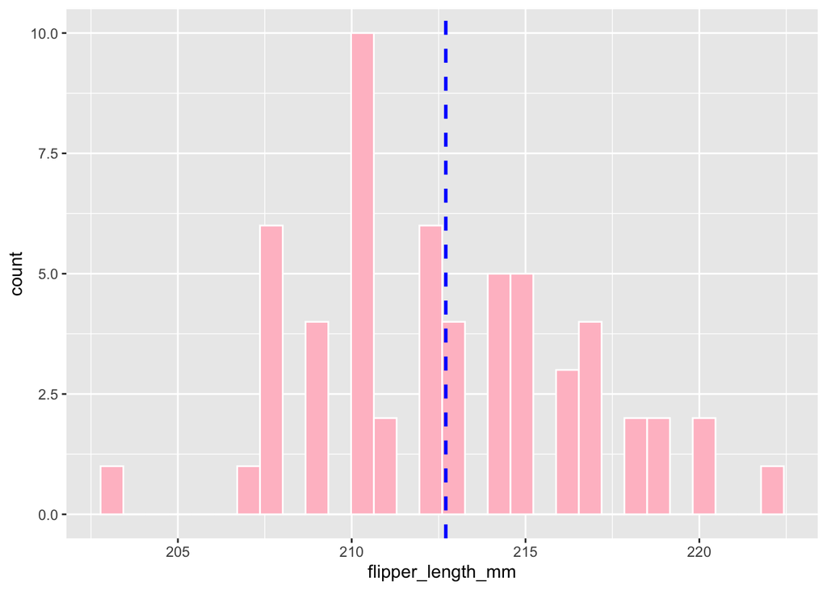

```r
avg_flip_fem <- ggplot(data = penguins_fem,
                       mapping = aes(flipper_length_mm))+
  geom_histogram(colour= "white", fill="pink")+ #plot flipper length densities
  geom_vline(aes(xintercept=mean(flipper_length_mm, na.rm=T)),    #line for meann filpper length
               color="blue", linetype="dashed", size=1)
avg_flip_fem
```

B. OK, this is pretty normal, with a mean of 212.71 and sd of 3.9. Make a grid to search a number of values around that mean and SD, just as you did for likelihood. Let’s say 100 values of each parameter.

```r
cross_peng <- crossing(m= seq(210,220, length.out = 100), s= seq(2,6, length.out=100)) #cross our mean with sd. 100 values with a somewhat center arounnd our known values
```

C. Write a function that will give you the numerator for any combination of m and s! This is just the same as writing a function for likelihood, but including an additional multiplier of p(H), when putting in the likelihood. Let’s assume a prior for m of dnorm(210, 50) and for s of dunif(1,10) - so, pretty weak!

So, we want p(m, s|flipper length)*p(m)*p(s).

BUT - small problem. These numbers get so vanishingly small, we can no longer do calculations with them. So, for any probability density you use, add log=TRUE and take a sum instead of products or multiplication, as

log(p(D|H)p(H))=log(p(D|H))+log(p(H))

```r
bayes_num <- function(m,s){
  # p(H|D) ~ p(D|H)*p(H)
  # log(p(H|D)) = log(p(D|H)) + log(p(H)) is what we are after
  # sum log likelihood + sum of the log of our priors

  # log(p(D|H)) - log likelihood
  # sum(dnorm(data, parameters, log = TRUE))
  sum(dnorm(penguins_fem$flipper_length_mm, m, s, log=TRUE),

    # log(p(H)) = log(p(s)) + log(p(m))  - log prior
    dunif(s, 1,10, log=TRUE),
    dnorm(m, mean = 210, sd = 50, log = TRUE))
}
```

Note: log(p(d)) = log(sum(exp(p(D|H)p(H))))

```r
#P(H|D) num- P(D)

num2 <- cross_peng%>%
  rowwise() %>% #take grid and then go row by row and find numerator
  mutate(num= bayes_num(m,s))

pd= log(sum(exp(num2$num))) # pd formula


post_full <- num2 %>%
  rowwise() %>% #take num function and go row by row annd then add a col with posterior by sub num from p(D) value
  mutate(posterior= num - pd)

post_full
```

```
## # A tibble: 10,000 x 4
## # Rowwise:
##        m     s   num posterior
##    <dbl> <dbl> <dbl>     <dbl>
##  1   210  2    -262.     -99.8
##  2   210  2.04 -257.     -94.7
##  3   210  2.08 -252.     -89.9
##  4   210  2.12 -247.     -85.3
##  5   210  2.16 -243.     -81.1
##  6   210  2.20 -239.     -77.2
##  7   210  2.24 -236.     -73.5
##  8   210  2.28 -232.     -70.0
##  9   210  2.32 -229.     -66.8
## 10   210  2.36 -226.     -63.7
## # … with 9,990 more rows
```

6. Final Project Thinking We’re at the half-way point in the course, and after the mid-term, it’s time to start thinking about your final project. So…. I want to know a bit about what you’re thinking of!

A. What is the dataset you are thinking of working with? Tell me a bit about what’s in it, and where it comes from.

I’m going to work with the PIE long term data set from our lab. It has EVERYTHING! This is apart of a long term research project conducted at PIE to sample across space and time in order to predict/observe the impact of climate change on marshes. There are sediment cores, % cover, sticky trap, bird counts, video, and pitfall data.

B. What question do you want to ask of that data set?

I want to look at wrack distribution over space and time. I will use this as preliminary data for my project. I also want to gain a better understanding on other aspects of the data so I likely will see if there is any correlation between changes in wrack and soil biogeochemistry, plant composition, herbivore counts, etc.

EC C. Wanna make a quick visualization of some aspect of the data that might be provocative and interesting?

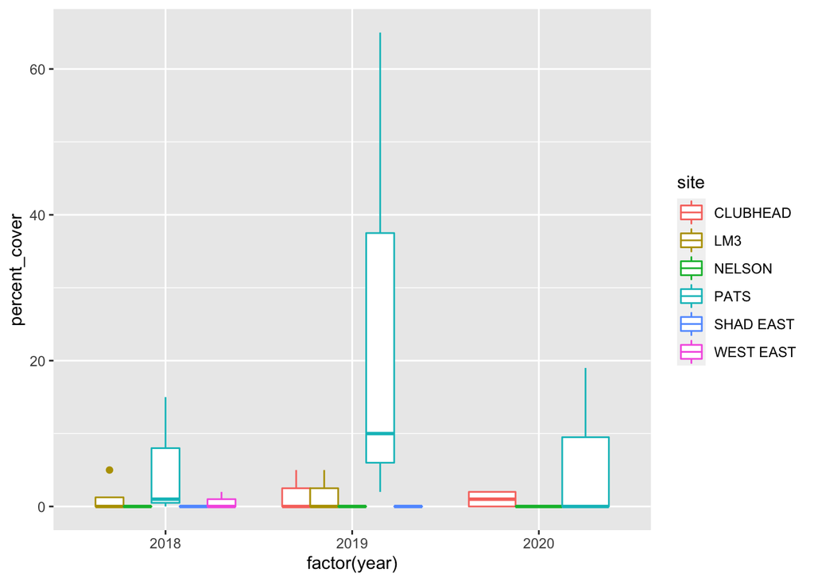

```r
setwd("/Users/wendiwhite/Desktop/Ecology/UMass Boston Masters/UMass Masters classes/bio stats 607/data")
wrack_det <- read.csv("wrack_PIE.csv") #read in dataset


wrack_wrack <- wrack_det%>% #filter for wrack and site
    filter(type== "wrack", site== c("CLUBHEAD", "LM3", "NELSON","PATS",
                                  "SHAD EAST","WEST EAST"))%>%
  na.omit(wrack_det)

wrack_detritus <- wrack_det%>% #filter for detritus data
  filter(type== "detritus")%>%
  na.omit(wrack_det)

wrack_plot <- ggplot(data = wrack_wrack, #plot how % cover of wrack changed over time
                     mapping = aes(x= factor(year),
                                   y= percent_cover,
                                   color= site))  +
              scale_x_discrete()+
               geom_boxplot(position= "dodge")

wrack_plot
```

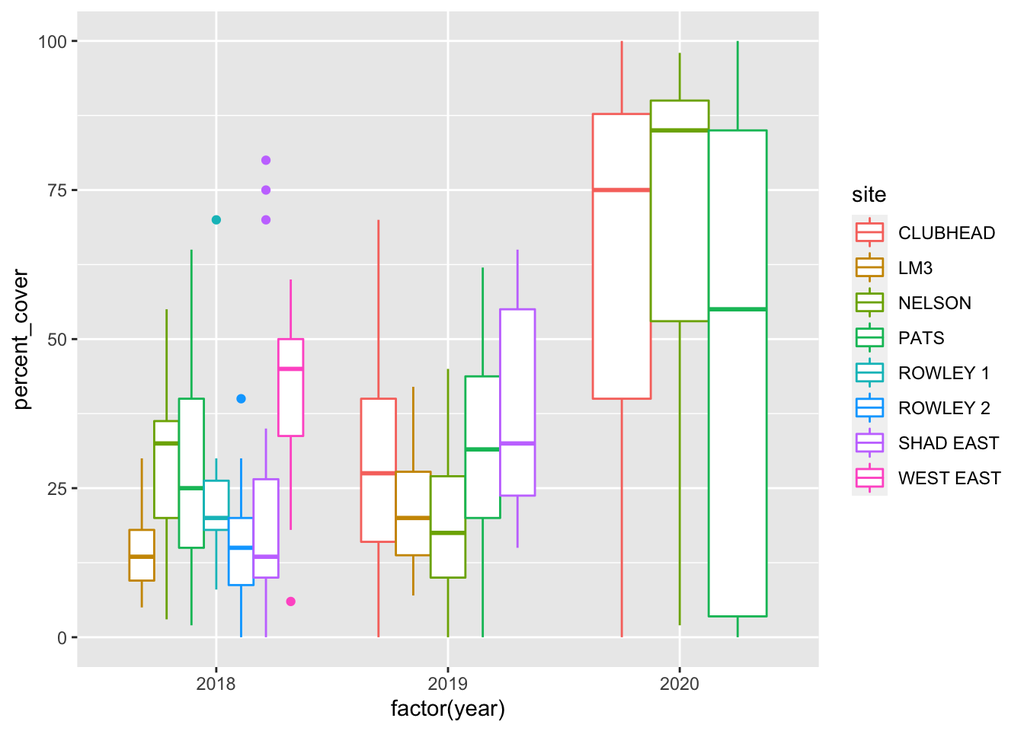

```r
det_plot <- ggplot(data = wrack_detritus, #plot how % cover of detritus changed over time
                   mapping = aes(x= factor(year),
                                 y= percent_cover,
                                 color= site))  +
         scale_x_discrete()+
         geom_boxplot(position= "dodge")
det_plot
```